# PDX Energy Spatial Regression Methods

Alec Trusty

November 6, 2017

## Introduction

The purpose of this report is to highlight my methods in developing a spatial regression model of average annual energy use at the census block group level with various structural and sociodemographic explanatory variables.

First, I load in the required R packages for the analysis:

```r
require(dplyr)
require(foreign)
require(rpostgis)
require(RPostgreSQL)
require(sp)
require(spdep)
require(rgeos)
require(leaflet)
require(car)
require(plotly)
require(latticeExtra)
require(rgdal)
options(stringsAsFactors = F)
setwd("/home/atrusty/SUPR/Energy_Research/Energy_Burden/SR_Transfer/")
```

## Data Clean-Up

```r
cbg <- readOGR("Energy_Burden/Metro_EnergyBurden_11817.shp")
#Calculate density and remove the lowest density block groups
cbg$cbg_area <- sapply(slot(cbg, "polygons"), slot, "area") #Create an area column
cbg <- subset(cbg, cbg$cbg_area < 5.0e+07 & cbg$cbg_area > 1e+06) #visually removed the large and very small block groups
cbg <- subset(cbg, cbg$sfr_nt > 40) # Subset CBGs with less than 40 SFR (As Chang et al did)

#Impute Medians
# There Shouldn't be many NA's
medePuter <- function(x){
  x<-as.numeric(as.character(x)) #first convert each column into numeric if it is from factor
  x[is.na(x)] =median(x, na.rm=TRUE) #convert the item with NA to median value from the column
  x #display the column
}

cbg@data <- as.data.frame(apply(cbg@data,2,medePuter)) #Imputes medians for all of the missing independent variables
```

## Normality

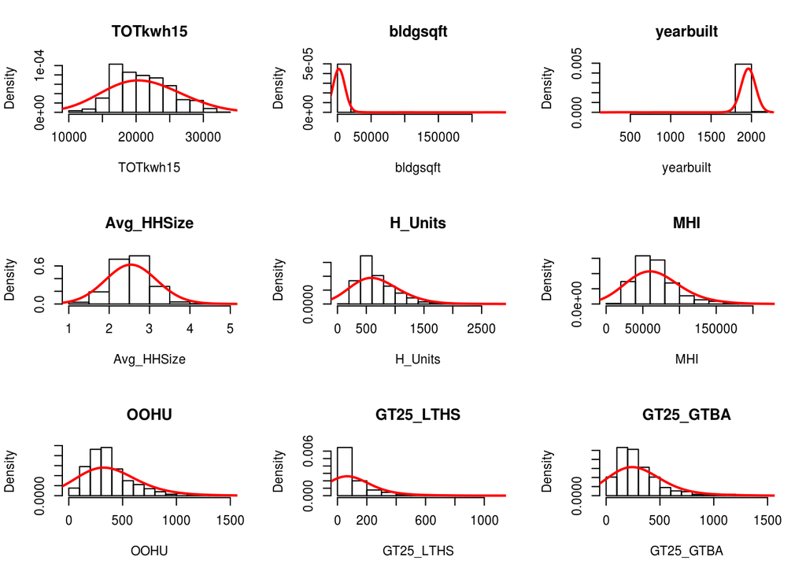

```r
vars<-c("bldgsqft", "yearbuilt", "Avg_HHSize","H_Units", "MHI", "OOHU", "GT25_LTHS","GT25_GTBA", "Pop_Under1", "Pop_65Over", "Pop_White", "Pop_Black", "Pop_Hisp", "gis_acres", "mfr_n", "u_tot")

par(mfrow=c(3,3))

#Making plots for all variables:
invisible(lapply(c("TOTkwh15", vars[1:8]), function(x){
  hist(cbg@data[,x],main=paste0(x),xlab=x,freq=F)
  lines(density(cbg@data[,x],bw=sd(cbg@data[,x])),col="red",lwd=2)
}))
```

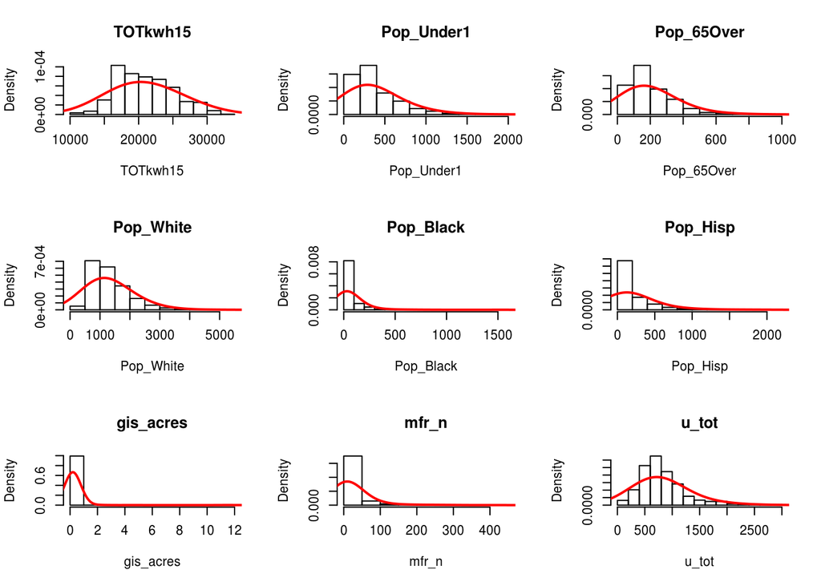

```r
par(mfrow=c(3,3))

#Making plots for all variables:
invisible(lapply(c("TOTkwh15", vars[9:16]), function(x){
  hist(cbg@data[,x],main=paste0(x),xlab=x,freq=F)
  lines(density(cbg@data[,x],bw=sd(cbg@data[,x])),col="red",lwd=2)
}))
```

## Explanatory Variable Clean-Up

```r
cbg <- subset(cbg, cbg$yearbuilt > 1800) #Anything with an average age of 1800 or older probably isn't accurate..

cbg$log_bldgsqft <- log(1+cbg$bldgsqft)
cbg$log_GT25_LTHS <- log(1+cbg$GT25_LTHS)
cbg$log_GT25_GTBA<- log(1+cbg$GT25_GTBA)
cbg$log_Under18 <- log(1+cbg$Pop_Under1)
cbg$log_Over65 <- log(1+cbg$Pop_65Over)
cbg$log_Black  <- log(1+cbg$Pop_Black)
cbg$log_Hisp <- log(1+cbg$Pop_Hisp)
cbg$log_acres <- log(1+cbg$gis_acres)
cbg$log_mfrn <- log(1+cbg$mfr_n)
```

Explanatory variable distribution after log transformation:

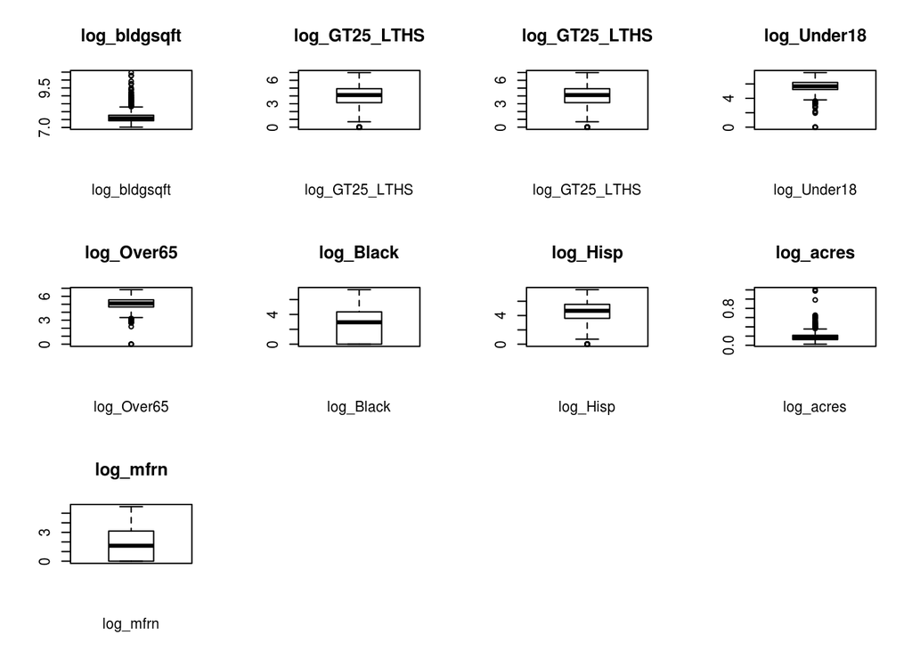

```r
bpvars <- c("log_bldgsqft"
        , "log_GT25_LTHS"
        , "log_GT25_LTHS"
        , "log_Under18"
        , "log_Over65"
        , "log_Black"
        , "log_Hisp"
        , "log_acres"
        , "log_mfrn")

par(mfrow=c(3,4))
invisible(lapply(bpvars, function(x){
  boxplot(cbg@data[,x],main=paste0(x),xlab=x)
}))
```

Log transformation did not ameliorate the skewed distribution of many explanatory variables. Average bldgsqft is still has a ton of outliers… Since we know building size is very important, lets remove some of those outliers.

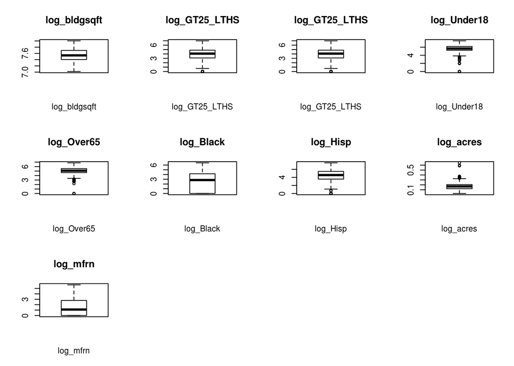

```r
cbg_redu <- subset(cbg, cbg$bldgsqft < 3000)


par(mfrow=c(3,4))
invisible(lapply(bpvars, function(x){
  boxplot(cbg_redu@data[,x],main=paste0(x),xlab=x)
}))
```

Removing outlying block group sample sizes and average building sizes:

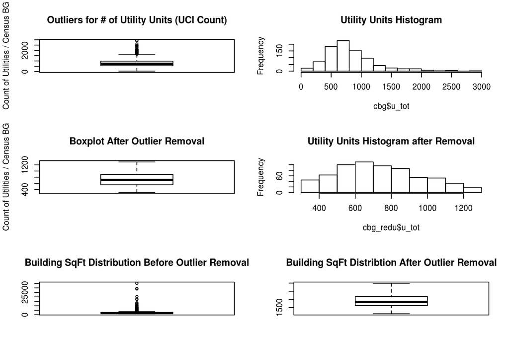

```r
cbg_redu <- subset(cbg_redu, cbg_redu$u_tot > 300 & cbg_redu$u_tot < 1300) # Block groups within similar range of utility samples

par(mfrow = c(3,2))
boxplot(cbg$u_tot, main = "Outliers for # of Utility Units (UCI Count)", ylab = "Count of Utilities / Census BG")
hist(cbg$u_tot, main = "Utility Units Histogram")
boxplot(cbg_redu$u_tot, main = "Boxplot After Outlier Removal", ylab = "Count of Utilities / Census BG")
hist(cbg_redu$u_tot, main = "Utility Units Histogram after Removal")
boxplot(cbg$bldgsqft, main = "Building SqFt Distribution Before Outlier Removal")
boxplot(cbg_redu$bldgsqft, main = "Building SqFt Distribtion After Outlier Removal")
```

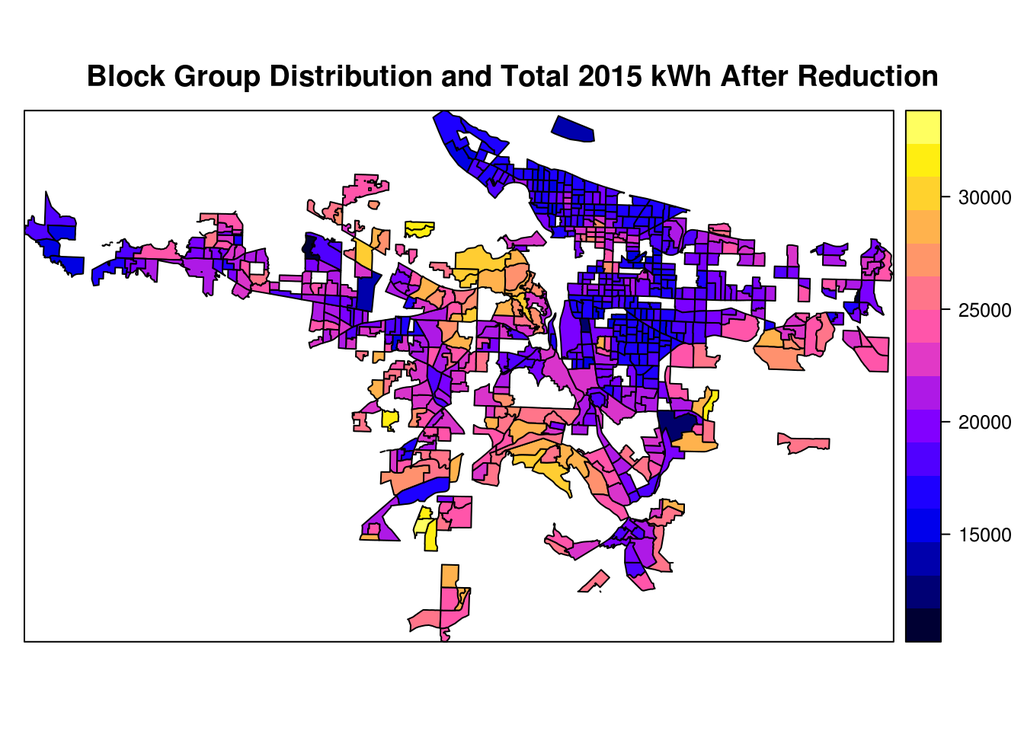

```r
spplot(cbg_redu, zcol="TOTkwh15", main = "Block Group Distribution and Total 2015 kWh After Reduction") #Map it just for funzies
```

## Correlation

Now that we’ve got a cleaner dataset, let’s assess the correlation between total average annual energy use of a block group and our explanatory variables.

```r
vars2<-c("log_bldgsqft", "Avg_HHSize","H_Units", "MHI", "OOHU", "log_GT25_LTHS","log_GT25_GTBA", "log_Under18", "log_Over65", "Pop_White", "log_Black", "log_Hisp", "log_acres", "log_mfrn")

#Assessing Correlation:
tl_cor<-cor(cbg_redu@data[,c("TOTkwh15",vars2)])[,1]

tl_cor<-data.frame(Variable=names(tl_cor),r = as.vector(tl_cor));tl_cor
```

```
##         Variable           r
## 1       TOTkwh15  1.00000000
## 2   log_bldgsqft  0.54563906
## 3     Avg_HHSize  0.12741115
## 4        H_Units  0.05987287
## 5            MHI  0.58427516
## 6           OOHU  0.36624496
## 7  log_GT25_LTHS -0.30297829
## 8  log_GT25_GTBA  0.23866477
## 9    log_Under18  0.18724775
## 10    log_Over65  0.30628560
## 11     Pop_White  0.18561896
## 12     log_Black -0.24637875
## 13      log_Hisp -0.18328408
## 14     log_acres  0.57437874
## 15      log_mfrn -0.42598687
```

Looks like H_Units and log_Under5 are unlikely to effect it the model much.

```r
cbg_redu <- cbg_redu[,c("TOTkwh15", "log_bldgsqft", "yearbuilt", "Avg_HHSize", "MHI", "OOHU", "log_GT25_LTHS","log_GT25_GTBA", "log_Under18", "log_Over65", "Pop_White", "log_Black", "log_Hisp", "log_acres", "log_mfrn")]
```

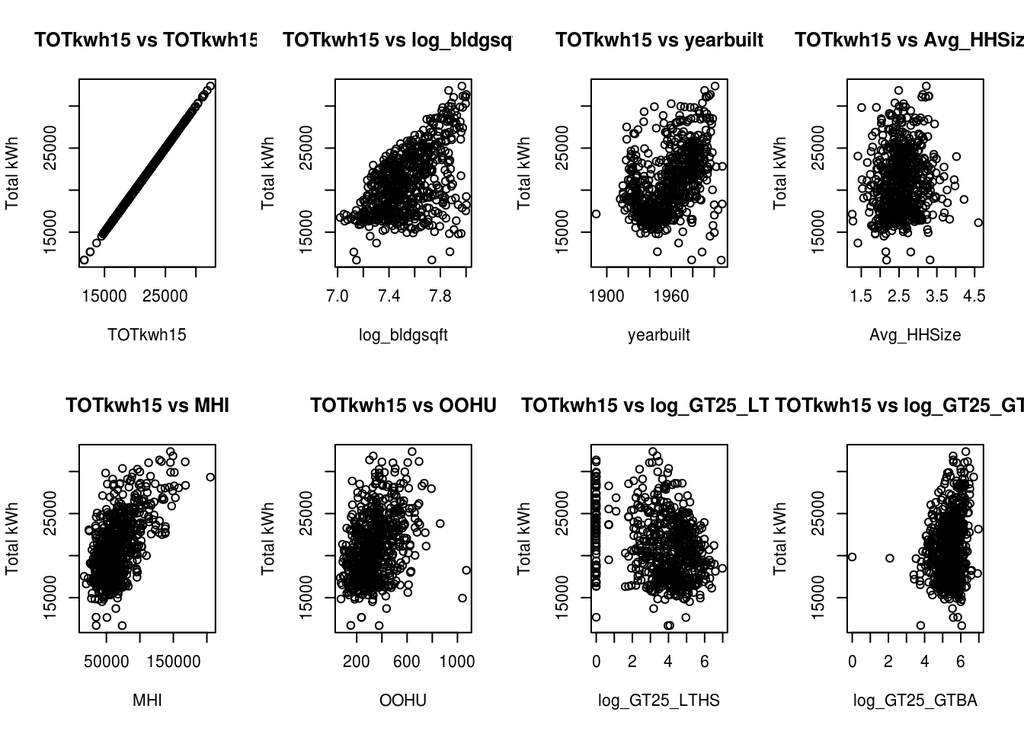

```r
finvars <- c("log_bldgsqft", "yearbuilt", "Avg_HHSize", "MHI", "OOHU", "log_GT25_LTHS","log_GT25_GTBA", "log_Under18", "log_Over65", "Pop_White", "log_Black", "log_Hisp", "log_acres", "log_mfrn")

par(mfrow=c(2,4))

#Scatter Plots for All Variables:
invisible(lapply(c("TOTkwh15", finvars[1:7]), function(x) {
  plot(cbg_redu@data$TOTkwh15 ~ cbg_redu@data[,x],main=paste0("TOTkwh15 vs ", x),xlab=x,ylab="Total kWh")
}))
```

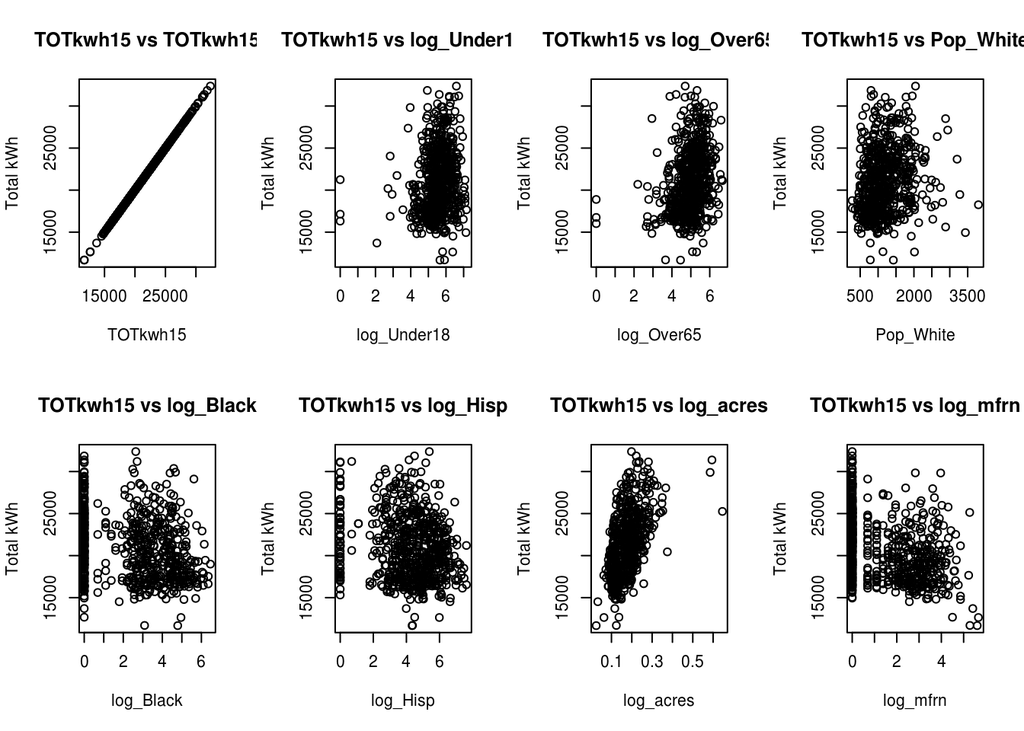

```r
par(mfrow=c(2,4))

#Scatter plots for all Variables:
invisible(lapply(c("TOTkwh15", finvars[8:14]), function(x) {
  plot(cbg_redu@data$TOTkwh15 ~ cbg_redu@data[,x],main=paste0("TOTkwh15 vs ", x),xlab=x,ylab="Total kWh")
}))
```

## OLS Regression

```r
ols <- lm(TOTkwh15~., data = cbg_redu)
summary(ols)
```

```
##
## Call:
## lm(formula = TOTkwh15 ~ ., data = cbg_redu)
##
## Residuals:
##     Min      1Q  Median      3Q     Max
## -8925.4 -1062.3    -0.1  1144.9  7407.5
##
## Coefficients:
##                 Estimate Std. Error t value Pr(>|t|)
## (Intercept)   -1.344e+05  9.041e+03 -14.862  < 2e-16 ***
## log_bldgsqft   6.123e+03  4.848e+02  12.630  < 2e-16 ***
## yearbuilt      5.234e+01  4.245e+00  12.330  < 2e-16 ***
## Avg_HHSize    -2.255e+02  2.549e+02  -0.885  0.37673
## MHI            4.084e-02  4.772e-03   8.558  < 2e-16 ***
## OOHU          -1.566e+00  8.726e-01  -1.794  0.07328 .
## log_GT25_LTHS -1.931e+02  6.697e+01  -2.883  0.00407 **
## log_GT25_GTBA  1.103e+02  1.596e+02   0.691  0.48954
## log_Under18    2.316e+02  1.585e+02   1.461  0.14445
## log_Over65     6.761e+02  1.333e+02   5.073 5.13e-07 ***
## Pop_White     -1.425e-01  2.785e-01  -0.512  0.60911
## log_Black     -3.480e+01  4.069e+01  -0.855  0.39270
## log_Hisp      -4.914e+01  5.608e+01  -0.876  0.38122
## log_acres      1.100e+04  1.545e+03   7.123 2.85e-12 ***
## log_mfrn      -6.315e+02  5.687e+01 -11.103  < 2e-16 ***
## ---
## Signif. codes:  0 '***' 0.001 '**' 0.01 '*' 0.05 '.' 0.1 ' ' 1
##
## Residual standard error: 1890 on 641 degrees of freedom
## Multiple R-squared:  0.7579, Adjusted R-squared:  0.7526
## F-statistic: 143.3 on 14 and 641 DF,  p-value: < 2.2e-16
```

```r
car::vif(ols)
```

```
##  log_bldgsqft     yearbuilt    Avg_HHSize           MHI          OOHU
##      1.842202      1.571553      2.361788      2.945801      2.813166
## log_GT25_LTHS log_GT25_GTBA   log_Under18    log_Over65     Pop_White
##      2.266615      1.849242      2.813897      1.878858      3.612012
##     log_Black      log_Hisp     log_acres      log_mfrn
##      1.219742      1.728195      1.771241      1.436734
```

No variabes had a high VIF (> 4) and variables with an insignificant P-Value (p > 0.05) were removed.

Reduced Model:

```r
sfmod.redu <- lm(TOTkwh15~
                 + I(2017 - yearbuilt)
                 + log_bldgsqft
                 + MHI
                 + log_GT25_LTHS
                 + log_Over65
                 + log_acres
                 + log_mfrn, data= cbg_redu)
summary(sfmod.redu)
```

```
##
## Call:
## lm(formula = TOTkwh15 ~ +I(2017 - yearbuilt) + log_bldgsqft +
##     MHI + log_GT25_LTHS + log_Over65 + log_acres + log_mfrn,
##     data = cbg_redu)
##
## Residuals:
##     Min      1Q  Median      3Q     Max
## -9831.7 -1040.6    20.6  1176.9  7049.0
##
## Coefficients:
##                       Estimate Std. Error t value Pr(>|t|)
## (Intercept)         -2.898e+04  3.285e+03  -8.824  < 2e-16 ***
## I(2017 - yearbuilt) -5.020e+01  4.011e+00 -12.514  < 2e-16 ***
## log_bldgsqft         6.285e+03  4.542e+02  13.838  < 2e-16 ***
## MHI                  3.853e-02  3.776e-03  10.204  < 2e-16 ***
## log_GT25_LTHS       -2.411e+02  5.704e+01  -4.227 2.71e-05 ***
## log_Over65           5.697e+02  1.090e+02   5.224 2.36e-07 ***
## log_acres            1.107e+04  1.487e+03   7.446 3.08e-13 ***
## log_mfrn            -6.329e+02  5.578e+01 -11.346  < 2e-16 ***
## ---
## Signif. codes:  0 '***' 0.001 '**' 0.01 '*' 0.05 '.' 0.1 ' ' 1
##
## Residual standard error: 1891 on 648 degrees of freedom
## Multiple R-squared:  0.7549, Adjusted R-squared:  0.7523
## F-statistic: 285.2 on 7 and 648 DF,  p-value: < 2.2e-16
```

```r
car::vif(sfmod.redu)
```

```
## I(2017 - yearbuilt)        log_bldgsqft                 MHI
##            1.401041            1.614851            1.841852
##       log_GT25_LTHS          log_Over65           log_acres
##            1.641985            1.256359            1.638320
##            log_mfrn
##            1.380183
```

*OLS Results:*

Reduced model explains 75.5% of the variability in 2015 average total annual kWh at the census block group level. Average building and property size, median household income, and population over 65 years old are significantly and positively correlated with building energy use. Average building age, population with a high school diploma or lower, and total number of multifamily units per block group are significantly and negatively correlated with energy use.

## Spatial Regression

*Spatial Weights:* Creating a weights matrix with K-Nearest Neighbors and 5 neighbors to create a matrix from census block group centroids:

```r
tl_point<-gCentroid(cbg_redu,byid=T)

nb <-  knn2nb(knearneigh(tl_point, k = 5))

nb_lines<-spTransform(nb2lines(nb, proj4string = cbg_redu@proj4string, coords = coordinates(tl_point)), CRS("+proj=longlat +datum=WGS84"))
leaflet() %>% addProviderTiles(providers$OpenStreetMap) %>%
  addCircleMarkers(data=spTransform(tl_point,CRS("+proj=longlat +datum=WGS84"))
                   ,weight=2
                   ,color="black"
                   ,fillColor = "grey"
                   ,fillOpacity = 0.15
                   ,opacity= 1
                   ,radius=4) %>%
  addPolylines(data=nb_lines,color="red",weight=2)
```

[interactive chart not shown]

Assessing the correlation between each observation’s residual and the mean value of it’s neighbors residuals. There appears to be a positive spatial trend:

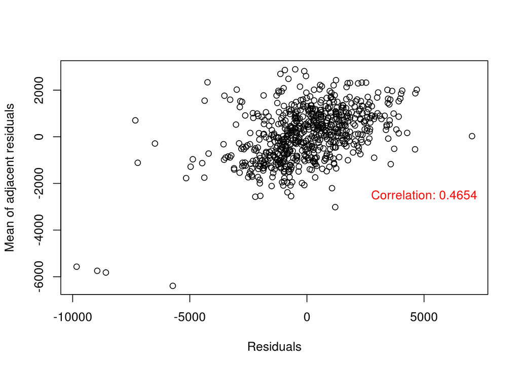

```r
#Creating Spatial lag and plotting
cbg_redu$resid <- sfmod.redu$residuals
resnb <- sapply(nb, function(x) mean(sfmod.redu$residuals[x]))
plot(sfmod.redu$residuals, resnb, xlab ='Residuals', ylab = 'Mean of adjacent residuals')
text(5000,-2500,paste0("Correlation: ", round(cor(cbg_redu$resid, resnb), 4)), col="red")
```

Testing spatial autocorrelation of the OLS residuals:

```r
weights <- nb2listw(nb)
moran.mc(cbg_redu$resid, weights, 999)
```

```
##
##  Monte-Carlo simulation of Moran I
##
## data:  cbg_redu$resid
## weights: weights
## number of simulations + 1: 1000
##
## statistic = 0.28515, observed rank = 1000, p-value = 0.001
## alternative hypothesis: greater
```

The residuals of the reduced OLS model are spatially autocorrelated, suggesting that a spatial regression model is necessary. Now we need to determine whether a spatial error or lag model would be more appropriate:

```r
lm.LMtests(sfmod.redu, listw=weights)
```

```
##
##  Lagrange multiplier diagnostics for spatial dependence
##
## data:
## model: lm(formula = TOTkwh15 ~ +I(2017 - yearbuilt) + log_bldgsqft
## + MHI + log_GT25_LTHS + log_Over65 + log_acres + log_mfrn, data =
## cbg_redu)
## weights: weights
##
## LMErr = 147.42, df = 1, p-value < 2.2e-16
```

## Spatial Error Model

Calculating a spatial error regression model based off of the reduced OLS model:

```r
sem <- errorsarlm(TOTkwh15~
                 + I(2017 - yearbuilt)
                 + log_bldgsqft
                 + MHI
                 + log_GT25_LTHS
                 + log_Over65
                 + log_acres
                 + log_mfrn, data= cbg_redu, weights)
summary(sem)
```

```
##
## Call:
## errorsarlm(formula = TOTkwh15 ~ +I(2017 - yearbuilt) + log_bldgsqft +
##     MHI + log_GT25_LTHS + log_Over65 + log_acres + log_mfrn,
##     data = cbg_redu, listw = weights)
##
## Residuals:
##       Min        1Q    Median        3Q       Max
## -7490.332  -919.409   -43.915   915.459  7024.123
##
## Type: error
## Coefficients: (asymptotic standard errors)
##                        Estimate  Std. Error  z value  Pr(>|z|)
## (Intercept)         -2.2877e+04  3.2548e+03  -7.0287 2.085e-12
## I(2017 - yearbuilt) -3.1954e+01  5.2542e+00  -6.0815 1.190e-09
## log_bldgsqft         5.4068e+03  4.3729e+02  12.3644 < 2.2e-16
## MHI                  3.4579e-02  3.4414e-03  10.0481 < 2.2e-16
## log_GT25_LTHS       -1.3740e+02  5.0440e+01  -2.7240   0.00645
## log_Over65           5.0071e+02  9.6112e+01   5.2096 1.892e-07
## log_acres            8.1422e+03  1.4780e+03   5.5089 3.612e-08
## log_mfrn            -5.6596e+02  4.9814e+01 -11.3614 < 2.2e-16
##
## Lambda: 0.63842, LR test value: 144.92, p-value: < 2.22e-16
## Approximate (numerical Hessian) standard error: 0.040419
##     z-value: 15.795, p-value: < 2.22e-16
## Wald statistic: 249.48, p-value: < 2.22e-16
##
## Log likelihood: -5803.847 for error model
## ML residual variance (sigma squared): 2588400, (sigma: 1608.8)
## Number of observations: 656
## Number of parameters estimated: 10
## AIC: 11628, (AIC for lm: 11771)
```

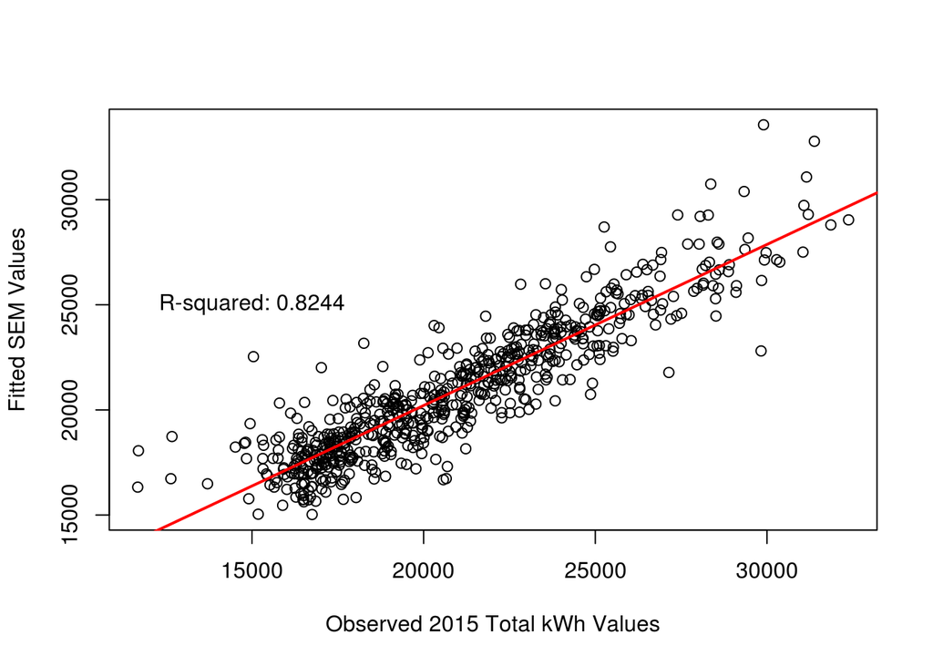

```r
plot(sem$fitted.values~cbg_redu$TOTkwh15, xlab = "Observed 2015 Total kWh Values", ylab = "Fitted SEM Values")
abline(lm(sem$fitted.values~cbg_redu$TOTkwh15), col="red", lwd=2)
text(15000,25000,paste0("R-squared: ", round(summary(lm(sem$fitted.values~cbg_redu$TOTkwh15))$adj.r.square,4)))
```

*Normality in Residuals:*

```r
## Testing Normality in Residuals
shapiro.test(sem$residuals) #indicates residuals are not normaly distributed.
```

```
##
##  Shapiro-Wilk normality test
##
## data:  sem$residuals
## W = 0.98139, p-value = 2.096e-07
```

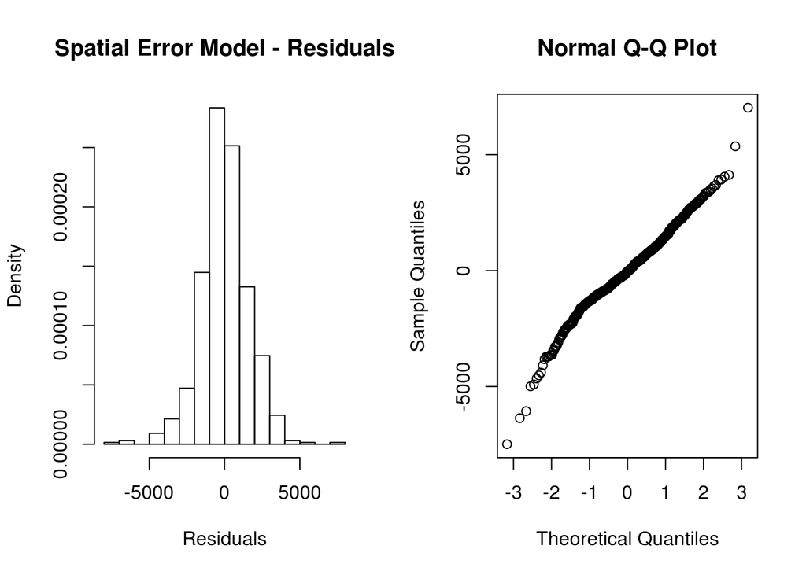

```r
#Check Qnorm
par(mfrow=c(1,2))
hist(sem$residuals, breaks=20, main = "Spatial Error Model - Residuals", xlab = "Residuals", freq = F)
qqnorm(sem$residuals)
```

*Assessing Heteroskedasticity:*

There does not appear to be a major relationship between the fitted values and residuals:

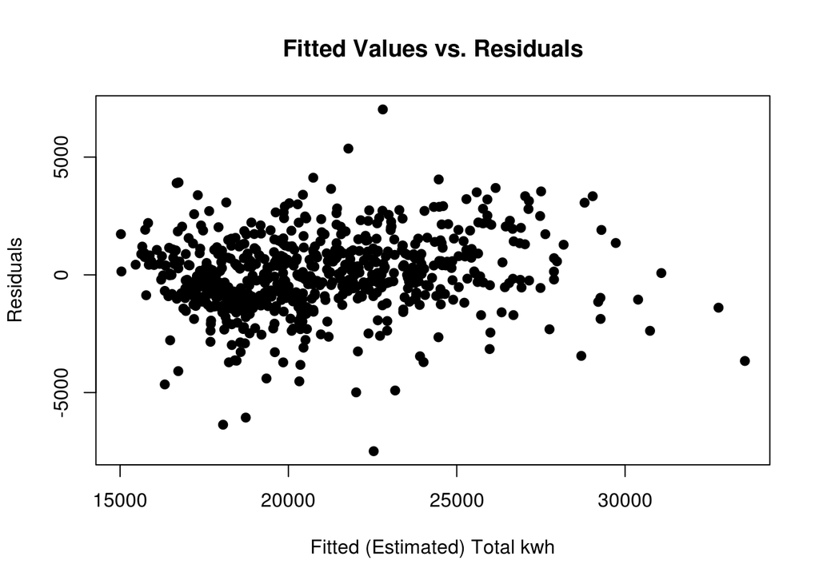

```r
plot(sem$residuals~sem$fitted.values, main = "Fitted Values vs. Residuals", xlab = "Fitted (Estimated) Total kwh", ylab = "Residuals", pch = 19)
```

*Assessing Spatial Autocorrelation of the Residuals:*

```r
# Spatial autocorrelation of residuals
moran.mc(sem$residuals, weights, 999)
```

```
##
##  Monte-Carlo simulation of Moran I
##
## data:  sem$residuals
## weights: weights
## number of simulations + 1: 1000
##
## statistic = -0.025229, observed rank = 169, p-value = 0.831
## alternative hypothesis: greater
```

## Discussion

*Energy Burden:*